# Angina

#### 2.1.5.3 Statistics of the new harmonized variable

History of angina

| Sample size | Missing values |
| --- | --- |
| 10274 | 13 |

Category

|  | 0 | 1 |
| --- | --- | --- |
| Frequency | 9359.00 | 902.00 |
| Percentage | 91.09 | 8.78 |

Type of missing

|  | 991 | 992 | 993 | 994 | 995 | 996 | 997 | 998 | 999 | NA |
| --- | --- | --- | --- | --- | --- | --- | --- | --- | --- | --- |
| Frequency | 0 | 0 | 0 | 0 | 0 | 0 | 4.00 | 9.00 | 0 | 0 |
| Percentage | 0 | 0 | 0 | 0 | 0 | 0 | 0.04 | 0.09 | 0 | 0 |

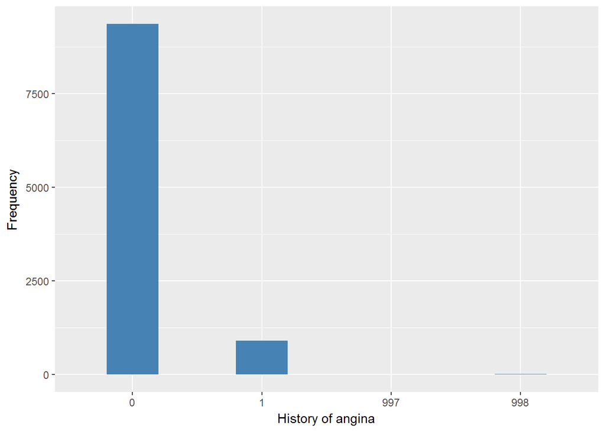

Age first diagnosed angina

| Sample size | Missing values |
| --- | --- |
| 10274 | 9783 |

Values

|  | No-missings | 991 | 992 | 993 | 994 | 995 | 996 | 997 | 998 | 999 | NA |
| --- | --- | --- | --- | --- | --- | --- | --- | --- | --- | --- | --- |
| Frequency | 491.00 | 0 | 0 | 0 | 0 | 0 | 9770.00 | 0 | 0 | 13.00 | 0 |
| Percentage | 4.78 | 0 | 0 | 0 | 0 | 0 | 95.09 | 0 | 0 | 0.13 | 0 |

Summary

| Min. | 1st Qu. | Median | Mean | 3rd Qu. | Max. |
| --- | --- | --- | --- | --- | --- |
| 25 | 50 | 59 | 58.28 | 65.5 | 86 |

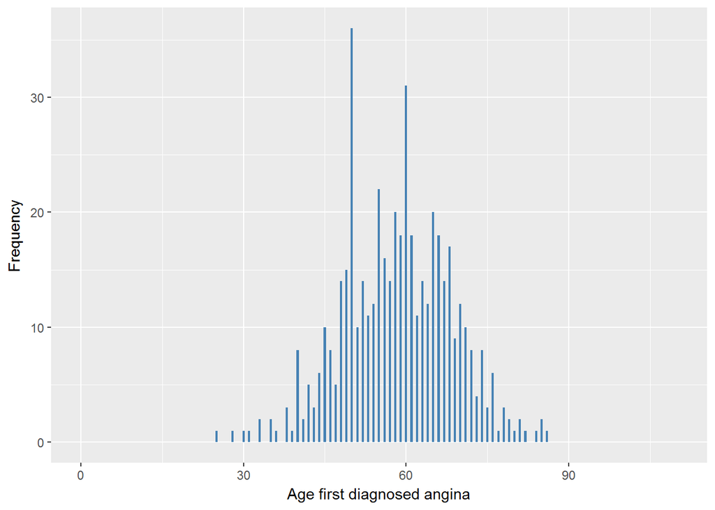

#### 2.1.5.4 Validation

|  | hediman==0->0 | hediman==1->1 | hediman==-9->997 | hediman==-8->998 |
| --- | --- | --- | --- | --- |
| BeforeH | 9359 | 902 | 4 | 9 |
| AfterH | 9359 | 902 | 4 | 9 |

### 2.1.6 Wave 6

#### 2.1.6.1 Study-specific variable description

| **Name** | `hediman` | `HeAga` |
| --- | --- | --- |
| **Label** | `CVD: angina diagnosis newly reported (merged)` | `Age first told had angina` |
| **Table name** | `wave_6_elsa_data_v2` | `wave_6_elsa_data_v2` |
| **Categories** | `1 = Mentioned` `0 = Not mentioned` | `continuous` |
| **Missings** | `-9 = Refusal` `-8 = Don't know` `-1 = Not applicable` | `-9 = Refusal` `-8 = Don't know` `-1 = Not applicable` |
| **Description** |  |  |

hediman

| Sample size | Missing values |
| --- | --- |
| 10601 | 11 |

Category

|  | 0 | 1 |
| --- | --- | --- |
| Frequency | 10475.00 | 115.00 |
| Percentage | 98.81 | 1.08 |

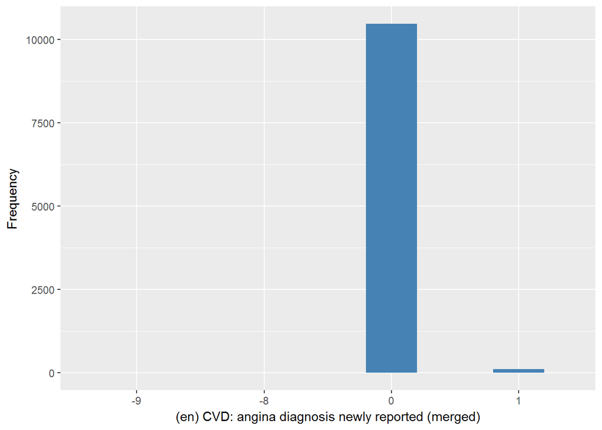

HeAga

| Sample size | Missing values |
| --- | --- |
| 10601 | 10568 |

Summary

| Min. | 1st Qu. | Median | Mean | 3rd Qu. | Max. |
| --- | --- | --- | --- | --- | --- |
| 24 | 44 | 50 | 49.88 | 55 | 76 |

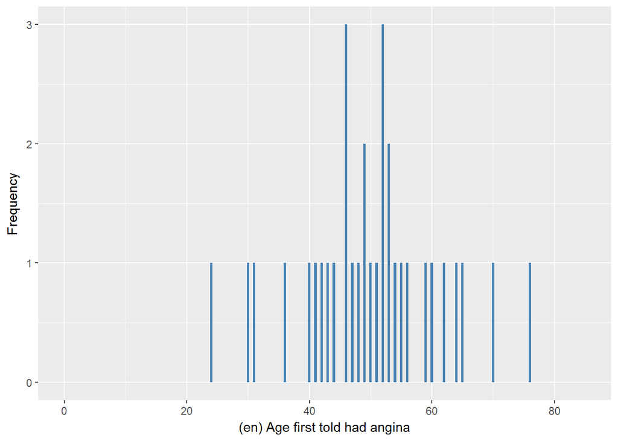

#### 2.1.6.2 Harmonisation algorithm

To compute `h_angina` from the study-specific variable it has to be recoded as follows:

- `h_angina previous == 1 or hediman == 1 into 1`
- `h_angina previous != -1 and hediman == -9 into 997`
- `h_angina previous != -1 and hediman == -8 into 998`
- `h_angina previous != 1 and hediman == 0 into 0`

To compute `h_angina_age` from the study-specific variable it has to be recoded as follows:

- `if h_angina == 1, h_angina_age = HeAga`
- `if h_angina == 0, h_angina_age = 996`
- `-9 into 997`
- `-8 into 998`
- `-1 into 996`
- `otherwise, h_angina_age = 999`

**R script:**

```r
ELSA_w6 <- left_join(ELSA_w6, ELSA_ds, by = "id")

# Categorical variable harmonization
ELSA_ds_w6 <- tibble(id = ELSA_w6$id)
ELSA_ds_w6$h_angina <- rep(999, length(ELSA_w6$id))
ELSA_ds_w6$h_angina[which(ELSA_w6$h_angina == 1 | ELSA_w6$hediman == 1)] <- 1
ELSA_ds_w6$h_angina[which((ELSA_w6$h_angina != 1 | is.na(ELSA_w6$h_angina)) &
    ELSA_w6$hediman == 0)] <- 0
ELSA_ds_w6$h_angina[which((ELSA_w6$h_angina != 1 | is.na(ELSA_w6$h_angina)) &
    ELSA_w6$hediman == -9)] <- 997
ELSA_ds_w6$h_angina[which((ELSA_w6$h_angina != 1 | is.na(ELSA_w6$h_angina)) &
    ELSA_w6$hediman == -8)] <- 998

# Continuous variable harmonization
ELSA_ds_w6$h_angina_age <- rep(999, length(ELSA_w6$id))
ELSA_ds_w6$h_angina_age[which(ELSA_ds_w6$h_angina == 0)] <- 996
ELSA_ds_w6$h_angina_age[which(ELSA_ds_w6$h_angina == 1)] <- car::recode(ELSA_w6$HeAga[which(ELSA_ds_w6$h_angina ==
    1)], "-1=996;-2=991;-8=998;-9=997")
ELSA_ds_w6$h_angina_age[which(ELSA_ds_w6$h_angina == 1 & !is.na(ELSA_w6$h_angina_age) &
    !ELSA_w6$h_angina_age %in% miss_values_vector)] <- ELSA_w6$h_angina_age[which(ELSA_ds_w6$h_angina ==
    1 & !is.na(ELSA_w6$h_angina_age) & !ELSA_w6$h_angina_age %in% miss_values_vector)]

# Update of global table
assign_merge <- function(endtib, sttib, log_vec = c(T), col_end_index = NULL,
    col_st_index = NULL) {
    newtib <- full_join(endtib, sttib, by = "id")
    row.names(newtib) <- newtib$id
    newtib[log_vec, col_end_index] <- newtib[log_vec, col_st_index]
    id_ind <- match("id", names(newtib))
    newtib <- newtib[, c(id_ind, col_end_index)]
    names(newtib)[2] <- "x"
    newtib$x <- car::recode(newtib$x, "NA=999")
    names(newtib)[2] <- names(endtib)[col_end_index]
    newtib
}
ELSA_ds_prov <- ELSA_ds[, c(1, 2)]
ELSA_ds_prov <- assign_merge(ELSA_ds_prov, ELSA_ds_w6, log_vec = ELSA_ds_w6$id,
    col_end_index = 2, col_st_index = 3)
ELSA_ds_aux <- ELSA_ds[, c(1, 3)]
ELSA_ds_aux <- assign_merge(ELSA_ds_aux, ELSA_ds_w6, log_vec = ELSA_ds_w6$id[which(ELSA_ds_w6$h_angina !=
    999)], col_end_index = 2, col_st_index = 4)
ELSA_ds <- ELSA_ds_prov
ELSA_ds$h_angina_age <- ELSA_ds_aux$h_angina_age
rm(ELSA_ds_prov)
rm(ELSA_ds_aux)
```

#### 2.1.6.3 Statistics of the new harmonized variable

History of angina

| Sample size | Missing values |
| --- | --- |
| 10601 | 10 |

Category

|  | 0 | 1 |
| --- | --- | --- |
| Frequency | 9745.00 | 846.00 |
| Percentage | 91.93 | 7.98 |

Type of missing

|  | 991 | 992 | 993 | 994 | 995 | 996 | 997 | 998 | 999 | NA |
| --- | --- | --- | --- | --- | --- | --- | --- | --- | --- | --- |
| Frequency | 0 | 0 | 0 | 0 | 0 | 0 | 4.00 | 6.00 | 0 | 0 |
| Percentage | 0 | 0 | 0 | 0 | 0 | 0 | 0.04 | 0.06 | 0 | 0 |

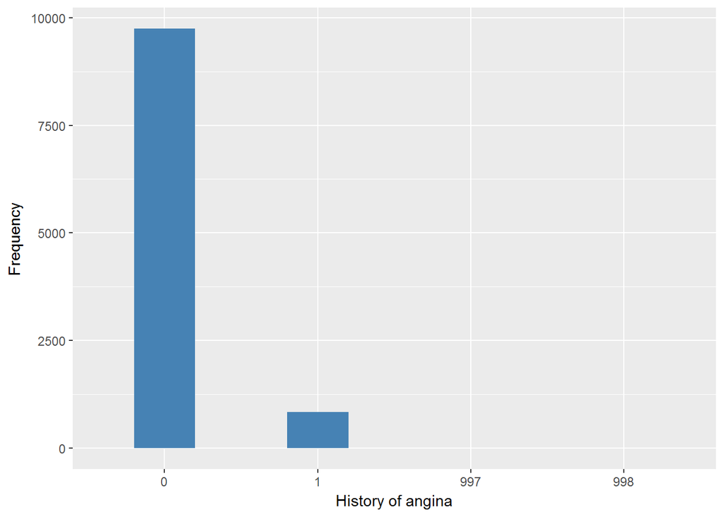

Age first diagnosed angina

| Sample size | Missing values |
| --- | --- |
| 10601 | 10150 |

Values

|  | No-missings | 991 | 992 | 993 | 994 | 995 | 996 | 997 | 998 | 999 | NA |
| --- | --- | --- | --- | --- | --- | --- | --- | --- | --- | --- | --- |
| Frequency | 451.00 | 0 | 0 | 0 | 0 | 0 | 10140.00 | 0 | 0 | 10.00 | 0 |
| Percentage | 4.25 | 0 | 0 | 0 | 0 | 0 | 95.65 | 0 | 0 | 0.09 | 0 |

Summary

| Min. | 1st Qu. | Median | Mean | 3rd Qu. | Max. |
| --- | --- | --- | --- | --- | --- |
| 24 | 50 | 57 | 57.13 | 64.5 | 85 |

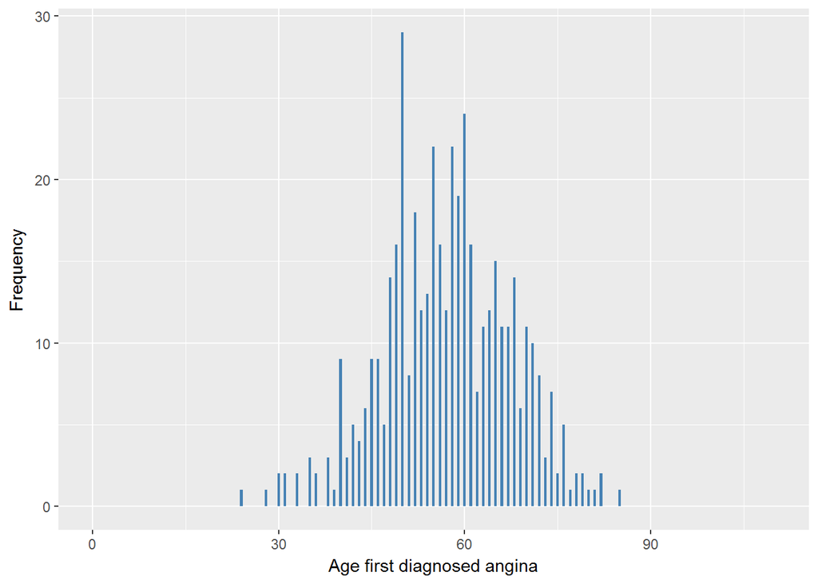

#### 2.1.6.4 Validation

|  | hediman==0->0 | hediman==1->1 | hediman==-9->997 | hediman==-8->998 |
| --- | --- | --- | --- | --- |
| BeforeH | 9745 | 846 | 4 | 6 |
| AfterH | 9745 | 846 | 4 | 6 |

### 2.1.7 Wave 7

#### 2.1.7.1 Study-specific variable description

| **Name** | `hediman` | `HeAga` |
| --- | --- | --- |
| **Label** | `CVD: angina diagnosis newly reported (merged)` | `Age first told had angina` |
| **Table name** | `wave_7_elsa_data` | `wave_7_elsa_data` |
| **Categories** | `1 = Mentioned` `0 = Not mentioned` | `continuous` |
| **Missings** | `-9 = Refusal` `-8 = Don't know` `-1 = Not applicable` | `-9 = Refusal` `-8 = Don't know` `-1 = Not applicable` |
| **Description** |  |  |

hediman

| Sample size | Missing values |
| --- | --- |
| 9666 | 6 |

Category

|  | 0 | 1 |
| --- | --- | --- |
| Frequency | 9447.00 | 213.0 |
| Percentage | 97.73 | 2.2 |

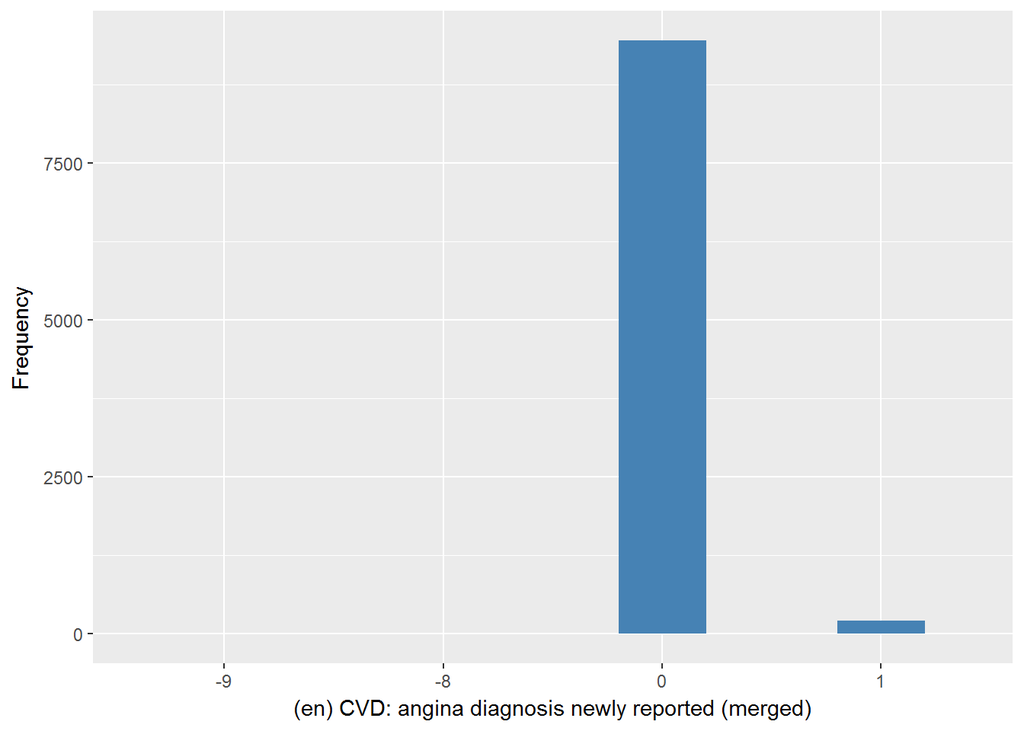

HeAga

| Sample size | Missing values |
| --- | --- |
| 9666 | 9653 |

Summary

| Min. | 1st Qu. | Median | Mean | 3rd Qu. | Max. |
| --- | --- | --- | --- | --- | --- |
| 45 | 48 | 50 | 51.46 | 52 | 67 |

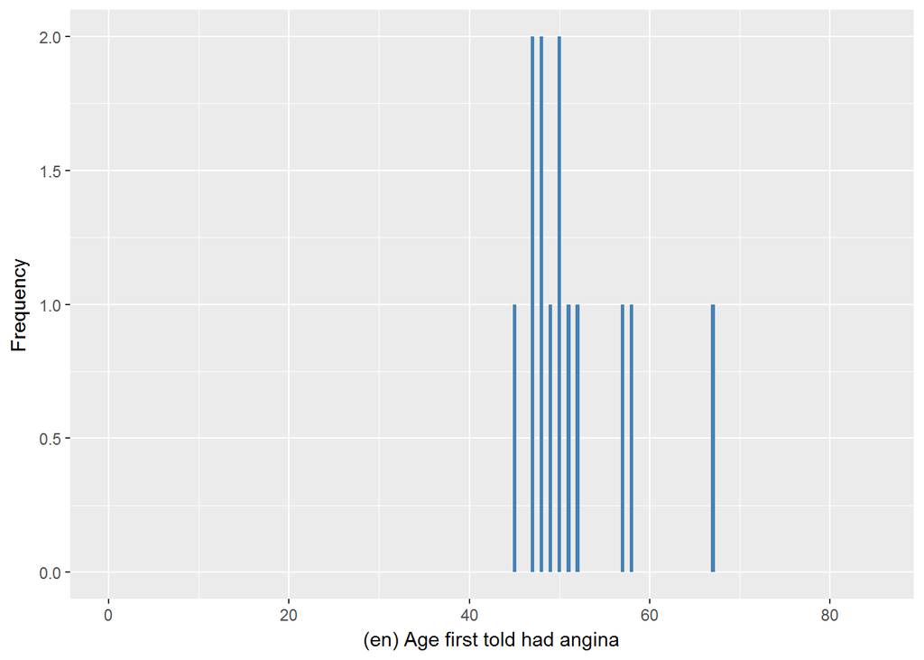

#### 2.1.7.2 Harmonisation algorithm

To compute `h_angina` from the study-specific variable it has to be recoded as follows:

- `h_angina previous == 1 or hediman == 1 into 1`
- `h_angina previous != -1 and hediman == -9 into 997`
- `h_angina previous != -1 and hediman == -8 into 998`
- `h_angina previous != 1 and hediman == 0 into 0`

To compute `h_angina_age` from the study-specific variable it has to be recoded as follows:

- `if h_angina == 1, h_angina_age = HeAga`
- `if h_angina == 0, h_angina_age = 996`
- `-9 into 997`
- `-8 into 998`
- `-1 into 996`
- `otherwise, h_angina_age = 999`

**R script:**

```r
ELSA_w7 <- left_join(ELSA_w7, ELSA_ds, by = "id")

# Categorical variable harmonization
ELSA_ds_w7 <- tibble(id = ELSA_w7$id)
ELSA_ds_w7$h_angina <- rep(999, length(ELSA_w7$id))
ELSA_ds_w7$h_angina[which(ELSA_w7$h_angina == 1 | ELSA_w7$hediman == 1)] <- 1
ELSA_ds_w7$h_angina[which((ELSA_w7$h_angina != 1 | is.na(ELSA_w7$h_angina)) &
    ELSA_w7$hediman == 0)] <- 0
ELSA_ds_w7$h_angina[which((ELSA_w7$h_angina != 1 | is.na(ELSA_w7$h_angina)) &
    ELSA_w7$hediman == -9)] <- 997
ELSA_ds_w7$h_angina[which((ELSA_w7$h_angina != 1 | is.na(ELSA_w7$h_angina)) &
    ELSA_w7$hediman == -8)] <- 998

# Continuous variable harmonization
ELSA_ds_w7$h_angina_age <- rep(999, length(ELSA_w7$id))
ELSA_ds_w7$h_angina_age[which(ELSA_ds_w7$h_angina == 0)] <- 996
ELSA_ds_w7$h_angina_age[which(ELSA_ds_w7$h_angina == 1)] <- car::recode(ELSA_w7$HeAga[which(ELSA_ds_w7$h_angina ==
    1)], "-1=996;-2=991;-8=998;-9=997")
ELSA_ds_w7$h_angina_age[which(ELSA_ds_w7$h_angina == 1 & !is.na(ELSA_w7$h_angina_age) &
    !ELSA_w7$h_angina_age %in% miss_values_vector)] <- ELSA_w7$h_angina_age[which(ELSA_ds_w7$h_angina ==
    1 & !is.na(ELSA_w7$h_angina_age) & !ELSA_w7$h_angina_age %in% miss_values_vector)]

# Update of global table
rm(ELSA_ds)
```

#### 2.1.7.3 Statistics of the new harmonized variable

History of angina

| Sample size | Missing values |
| --- | --- |
| 9666 | 6 |

Category

|  | 0 | 1 |
| --- | --- | --- |
| Frequency | 8908.00 | 752.00 |
| Percentage | 92.16 | 7.78 |

Type of missing

|  | 991 | 992 | 993 | 994 | 995 | 996 | 997 | 998 | 999 | NA |
| --- | --- | --- | --- | --- | --- | --- | --- | --- | --- | --- |
| Frequency | 0 | 0 | 0 | 0 | 0 | 0 | 1.00 | 5.00 | 0 | 0 |
| Percentage | 0 | 0 | 0 | 0 | 0 | 0 | 0.01 | 0.05 | 0 | 0 |

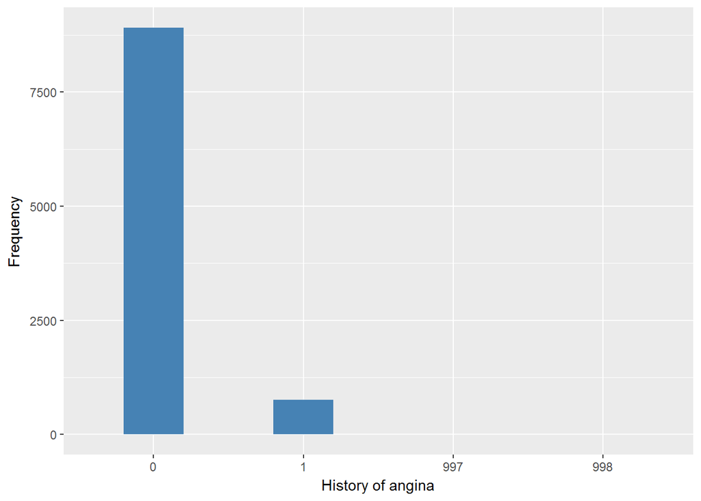

Age first diagnosed angina

| Sample size | Missing values |
| --- | --- |
| 9666 | 9301 |

Values

|  | No-missings | 991 | 992 | 993 | 994 | 995 | 996 | 997 | 998 | 999 | NA |
| --- | --- | --- | --- | --- | --- | --- | --- | --- | --- | --- | --- |
| Frequency | 365.00 | 0 | 0 | 0 | 0 | 0 | 9295.00 | 0 | 0 | 6.00 | 0 |
| Percentage | 3.78 | 0 | 0 | 0 | 0 | 0 | 96.16 | 0 | 0 | 0.06 | 0 |

Summary

| Min. | 1st Qu. | Median | Mean | 3rd Qu. | Max. |
| --- | --- | --- | --- | --- | --- |
| 24 | 50 | 57 | 56.79 | 64 | 85 |

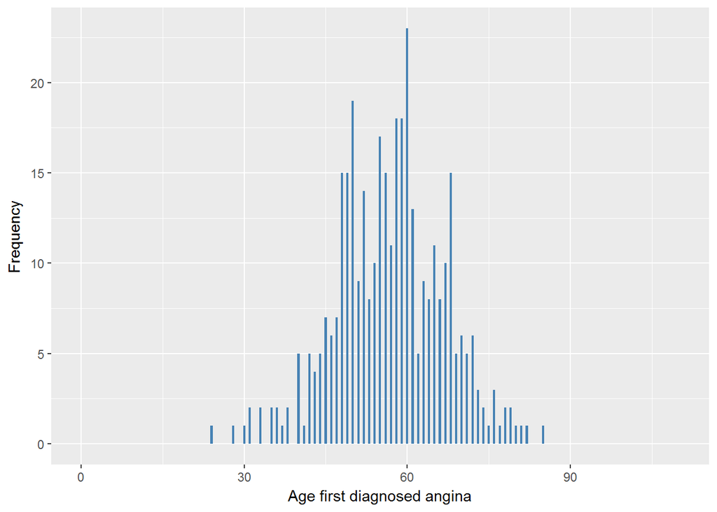

#### 2.1.7.4 Validation

|  | hediman==0->0 | hediman==1->1 | hediman==-9->997 | hediman==-8->998 |
| --- | --- | --- | --- | --- |
| BeforeH | 8908 | 752 | 1 | 5 |
| AfterH | 8908 | 752 | 1 | 5 |

## 2.2 Summary of descriptive statistics of the harmonised variable accross populations and waves

Two tables are generated:

1. Percentages of categories in each harmonised variable.
2. Frequencies and percentages of individuals with different trajectories. To avoid too large table, Only trajectories with percentages larger than 0.3 are shown.

**R script:**

```r
l.hds <- list(w1 = ELSA_ds_w1, w2 = ELSA_ds_w2, w3 = ELSA_ds_w3, w4 = ELSA_ds_w4,
    w5 = ELSA_ds_w5, w6 = ELSA_ds_w6, w7 = ELSA_ds_w7)

for (name in names(l.hds)) {
    aux_object <- l.hds[[name]]
    label(l.hds[[name]][[2]]) <- label(aux_object[[2]]) <- ds_label  # Text value assigned at the DS description, at the top
    l.hds[[name]][[2]] <- labelled(l.hds[[name]][[2]], labels = cat_label)
    label(l.hds[[name]][[3]]) <- label(aux_object[[3]]) <- ds_label_age  # Text value assigned at the DS description, at the top
    l.hds[[name]][[3]] <- labelled(l.hds[[name]][[3]], labels = cont_label)
    aux_object[[2]] <- car::recode(aux_object[[2]], "miss_values_vector=NA")
    aux_object[[2]] <- labelled(aux_object[[2]], labels = cat_label[1:2])
    m_name <- paste0("ELSA_m_ds_", name)
    assign(m_name, aux_object)
    rm(aux_object)
}

t.hds <- frq(l.hds[[1]][2])[[1]][, c(1, 2)]
for (i in seq_along(l.hds)) {
    t.hds[2 + i] <- frq(l.hds[[i]][2])[[1]][, 4]
}
t.hds[13, ] <- c("n", "sample size", length(l.hds[[1]][[2]]), length(l.hds[[2]][[2]]),
    length(l.hds[[3]][[2]]), length(l.hds[[4]][[2]]), length(l.hds[[5]][[2]]),
    length(l.hds[[6]][[2]]), length(l.hds[[7]][[2]]))
names(t.hds) <- c("val", "label", "w1", "w2", "w3", "w4", "w5", "w6", "w7")
kable(t.hds)
```

| val | label | w1 | w2 | w3 | w4 | w5 | w6 | w7 |
| --- | --- | --- | --- | --- | --- | --- | --- | --- |
| 0 | No | 90.45 | 89.55 | 90.67 | 91.41 | 91.09 | 91.93 | 92.16 |
| 1 | Yes | 9.48 | 10.38 | 9.28 | 8.44 | 8.78 | 7.98 | 7.78 |
| 991 | CAPI interviewer error | 0 | 0 | 0 | 0 | 0 | 0 | 0 |
| 992 | Impute | 0 | 0 | 0 | 0 | 0 | 0 | 0 |
| 993 | Disable to measure | 0 | 0 | 0 | 0 | 0 | 0 | 0 |
| 994 | Not attempt not done | 0 | 0 | 0 | 0 | 0 | 0 | 0 |
| 995 | Does not answer | 0 | 0 | 0 | 0 | 0 | 0 | 0 |
| 996 | Not applicable | 0 | 0 | 0.05 | 0 | 0 | 0 | 0 |
| 997 | Refuse | 0.02 | 0.01 | 0 | 0.06 | 0.04 | 0.04 | 0.01 |
| 998 | Do not know | 0.05 | 0.06 | 0 | 0.08 | 0.09 | 0.06 | 0.05 |
| 999 | Missing | 0 | 0 | 0 | 0 | 0 | 0 | 0 |
| NA | NA | 0 | 0 | 0 | 0 | 0 | 0 | 0 |
| n | sample size | 12099 | 9432 | 9771 | 11050 | 10274 | 10601 | 9666 |

```r
dbb <- merge(ELSA_m_ds_w1[, c("id", "h_angina")], ELSA_m_ds_w2[, c("id", "h_angina")],
    by = "id", suffixes = c(".w1", ".w2"), all = T)
dbb <- merge(dbb, ELSA_m_ds_w3[, c("id", "h_angina")], by = "id", all = T)
dbb <- merge(dbb, ELSA_m_ds_w4[, c("id", "h_angina")], by = "id", suffixes = c(".w3",
    ".w4"), all = T)
dbb <- merge(dbb, ELSA_m_ds_w5[, c("id", "h_angina")], by = "id", all = T)
dbb <- merge(dbb, ELSA_m_ds_w6[, c("id", "h_angina")], by = "id", suffixes = c(".w5",
    ".w6"), all = T)
dbb <- merge(dbb, ELSA_m_ds_w7[, c("id", "h_angina")], by = "id", all = T)
names(dbb) <- c("id", "w1", "w2", "w4", "w5")
v.dbb <- paste(dbb[, 2], dbb[, 3], dbb[, 4], dbb[, 5], dbb[, 6], dbb[, 7], dbb[,
    8], sep = "")
f.dbb <- frq(v.dbb)[[1]][, c(1, 2, 4)]
kable(f.dbb[f.dbb[, 3] >= 0.3, ])
```

|  | val | frq | raw.prc |
| --- | --- | --- | --- |
| 1 | 0000000 | 3904 | 21.12 |
| 3 | 000000NA | 560 | 3.03 |
| 6 | 00000NA0 | 60 | 0.32 |
| 8 | 00000NANA | 425 | 2.30 |
| 12 | 0000NA00 | 59 | 0.32 |
| 15 | 0000NANANA | 506 | 2.74 |
| 21 | 000NA000 | 109 | 0.59 |
| 31 | 000NANANANA | 789 | 4.27 |
| 40 | 00NA0000 | 99 | 0.54 |
| 64 | 00NANANANANA | 1124 | 6.08 |
| 80 | 0NA00000 | 88 | 0.48 |
| 100 | 0NA0NANANANA | 106 | 0.57 |
| 106 | 0NANA0000 | 66 | 0.36 |
| 118 | 0NANANA000 | 55 | 0.30 |
| 127 | 0NANANANANANA | 1837 | 9.94 |
| 128 | 1111111 | 267 | 1.44 |
| 129 | 111111NA | 71 | 0.38 |
| 131 | 11111NANA | 56 | 0.30 |
| 135 | 1111NANANA | 92 | 0.50 |
| 142 | 111NANANANA | 112 | 0.61 |
| 154 | 11NANANANANA | 150 | 0.81 |
| 174 | 1NANANANANANA | 245 | 1.33 |
| 201 | NANA00000 | 839 | 4.54 |
| 203 | NANA0000NA | 114 | 0.62 |
| 206 | NANA000NANA | 85 | 0.46 |
| 213 | NANA00NANANA | 118 | 0.64 |
| 218 | NANA0NA000 | 56 | 0.30 |
| 228 | NANA0NANANANA | 298 | 1.61 |
| 238 | NANANA0000 | 1608 | 8.70 |
| 240 | NANANA000NA | 248 | 1.34 |
| 245 | NANANA00NANA | 172 | 0.93 |
| 253 | NANANA0NANANA | 337 | 1.82 |
| 254 | NANANA1111 | 60 | 0.32 |
| 262 | NANANANA000 | 79 | 0.43 |
| 271 | NANANANANA00 | 922 | 4.99 |
| 273 | NANANANANA0NA | 260 | 1.41 |
| 276 | NANANANANANA0 | 500 | 2.70 |

# 3 Quality estimation

- We assume that if an individual answers it has angina in one wave, it has for all the next waves.